# EEG data processing using MNE-Python

# Overview

This document discusses the analysis pipeline for the experiment’s EEG data. We have written custom Python scripts to preprocess, organize, and analyze the data according to our defined experimental conditions.

# Downloading data

First, we need to ensure that the data is available locally. Both behavioral and EEG data are available on OSF. You may run the code below to download the data.

```r
# Uncomment the lines below to download the data:
# getBehaviorData()
# getEEGData()
```

We also source some R scripts we wrote to plot and analyze the data:

```r
source('ana/permutationTtest.R')
```

# EEG data pre-processing

## MirRevAdapt_Preprocessing_Funcs.py

We used MNE-Python to pre-process and analyze the data. As such, certain dependencies called in the Python scripts will rely on having MNE installed.

Our custom code implements the pre-processing steps described below. The user simply has to run the script to start pre-processing the EEG data. Note that with the amount of data within and across participants, along with the ICA fitting procedure, pre-processing will take several hours per participant. As such, we have saved the pre-processed epochs as part of the data downloaded, in case the user would want to skip this step.

### Triggers

Multiple events across trial types, and within each trial, correspond to unique EEG triggers (expressed as 5 digit integers in parentheses below). Descriptions of the trial events and trial types are found in the manuscript’s Methods section.

#### Triggers across trial types

The different trial types are: resting state (16148), aligned reaches (16149), first block of random rotation (16150), rotation training (16151), washout following rotation training (16152), second block of random rotation (16153), mirror reversal training (16154), washout following mirror training (16155). There is also a trigger at the end of the block for each trial type (16156).

#### Triggers within a trial

Within each trial, the triggers correspond to trial onset (16138), target onset (16139), go signal (16140), reach onset (16141), feedback onset (16142), feedback at home (16143), fixation onset (16144).

#### Triggers for target locations

Each target location across the workspace also corresponds to its own trigger. Each target is positioned in one of four quadrants, at a set distance from the vertical or horizontal midline axis. The list of all possible target locations and their triggers are found below:

Quadrant 1:  
Vertical, near: 16164; Vertical, mid 16165; Vertical, far: 16166

Horizontal, near: 16158; Horizontal, mid: 16159; Horizontal, far 16160

Quadrant 2:  
Vertical, near: 16184; Vertical, mid: 16185; Vertical, far: 16186

Horizontal, near: 16178; Horizontal, mid: 16179; Horizontal, far: 16180

Quadrant 3:  
Vertical, near: 16167; Vertical, mid: 16168; Vertical, far: 16169

Horizontal, near: 16161; Horizontal, mid: 16162; Horizontal, far 16163

Quadrant 4:  
Vertical, near: 16187; Vertical, mid: 16188; Vertical, far: 16189

Horizontal, near: 16181; Horizontal, mid: 16182; Horizontal, far: 16183

### Pre-processing steps

We collected data using a 32-channel BioSemi ActiveTwo system. Data were sampled at 512 Hz. Electrodes are positioned according to the international 10-20 system. We used the left and right mastoids as reference electrodes. We then applied a high-pass filter at 0.1 Hz, a low-pass filter at 200 Hz, and a notch filter at 60, 120, 180, and 240 Hz. Epochs were defined by aligning data to a specific event. As we are interested in EEG activity before and after the reaching movement, we aligned data to either the go signal onset (pre-movement) or the feedback onset (post-movement), and defined each epoch’s time window to range 2 seconds before and after the event.

For artifact removal, we fit an Independent Component Analysis (ICA; extended infomax with 1000 iterations) to the epoched data. We then used the ICLabel method to label the different output components. With this method, each component label is identified as coming from the brain, eye movements, or other artifacts with a corresponding probability. For our study, we only included components labelled as “brain” and “other” with a probability of greater than 80%. The other components either did not reach this threshold or were labelled as eye, muscle or other movement artifacts. Thus, we removed these artifacts when applying the ICA to the EEG data.

Finally, we downsampled the EEG data to 200 Hz. and generated the described pre-processed epochs for each participant across all their trials.

# Behavior data pre-processing

We then split the epochs into different conditions, dependent on participants’ behavioral performance throughout the experiment.

### Trial types

First, we split the data according to trial types. That is, we compared behavioral and EEG data across these trial types: aligned reaches, random rotation trials, rotation training, and mirror reversal training.

### Early versus Late training

We are interested in investigating how learning progresses throughout perturbation training. As such, we expect that participants should perform movements with more errors at the beginning of training, compared to later on in training. While we observe no learning or a more or less stable magnitude of errors for the aligned and random rotation trials, we do observe a reduction of errors for both rotation and mirror reversal trials. Thus, we split the epoched data into early training (first two blocks of training: 12 trials) and late training (last six blocks of training: 36 trials) for the rotation and mirror trial types. Given that the random rotation is introduced in two separate blocks prior to the rotation and mirror trials, we combined both blocks as they do not show differences in performance. From this combined set of trials, the first two blocks (12 trials) are considered as early training, while the last 4 blocks (24 trials) are considered as late training. Finally, since the aligned trials do not show any changes across trials, we used all 48 trials for analyses.

### Small versus Large errors

Initially, we grouped each epoch as having either a small error or large error. To do so, we took the lowest and highest 40% of errors across all trials per participant. This comes out to 36 trials each for small and large errors in both the rotation and mirror perturbation trial types. However, given the high variability of errors within and across participants, we noticed a lot of overlap in these error size conditions:

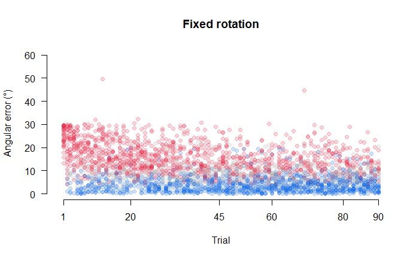

```r
plotAllROTErrors()
```

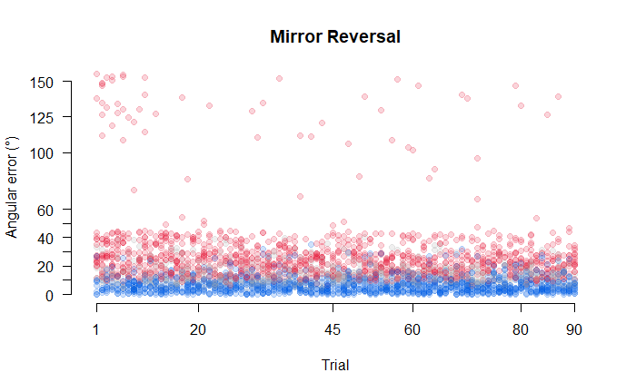

```r
plotAllMIRErrors()
```

The overlap for error sizes could act as a confound when comparing EEG activity between these error sizes, as the differences between the conditions may not be enough. Furthermore, we also observed more trials with extremely large errors for the mirror condition. For a few participants, these extremely large errors seem to be an outlier or only occur once. These issues with how we define our error conditions are also evident with the random perturbation:

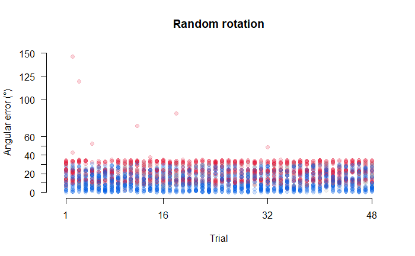

```r
plotAllRDMErrors()
```

Because of these issues, we decided to define our error size conditions to be more distinct with each other, and to remove the largest error size per participant. Thus, we defined our error size conditions as follows:

Rotation perturbation:  
We sorted all errors per participant in ascending order. We defined the small condition by taking 36 trials with the smallest errors (roughly equivalent number of trials to the 6 trial blocks we defined as late training, as we expect smaller errors once learning has occurred). We defined the large condition by taking 18 trials with the largest errors (roughly equivalent to the first 3 blocks of early training).

Mirror perturbation:  
First, we defined errors relative to each target location, as target location produces different error magnitudes for the mirror reversal perturbation. We then sorted all errors in ascending order for each participant, and defined small and large conditions similarly to the rotation perturbation.

Random perturbation:  
We defined errors relative to each target location as well, and we combined the two random perturbation blocks that each participant did. We then defined small and large errors similarly to the other two trial types.

The end result is that we have made our small and large conditions more distinct from each other:

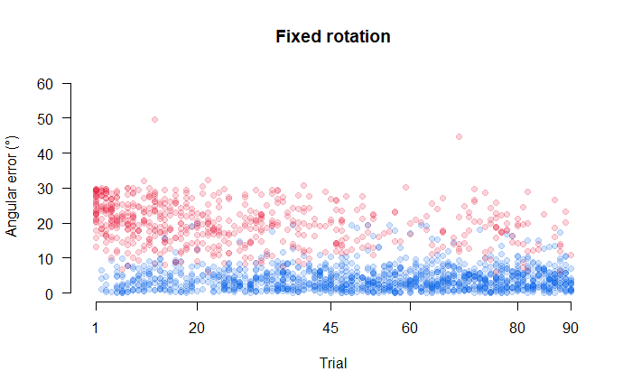

```r
plotAllROTSmallLargeErrors()
```

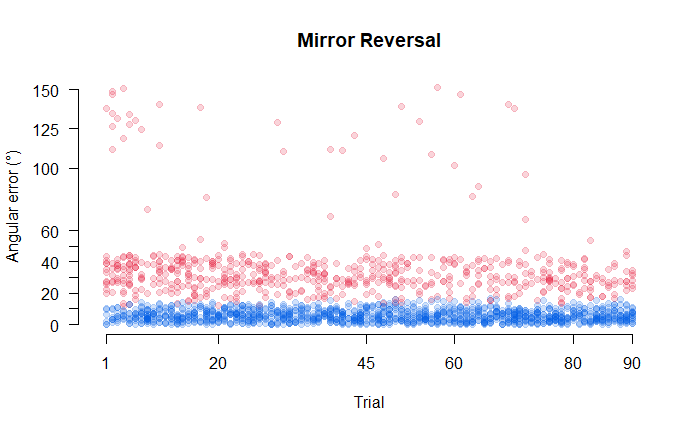

```r
plotAllMIRSmallLargeErrors()
```

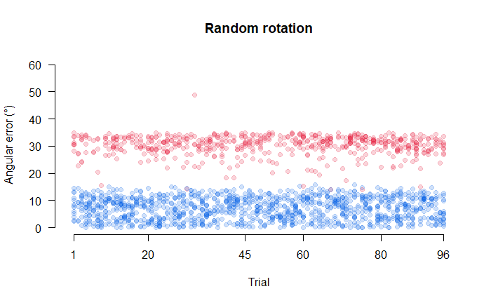

```r
plotAllRDMSmallLargeErrors()
```

The rest of the analyses compares Early Vs. Late training and Small Vs. Large errors across the trial (perturbation) types, during pre-movement or post-movement. We look at even-related potentials (ERP) and time frequency representations (TFR) to compare these conditions.

# Event related potentials (ERPs)

## Early Vs. Late Training: Post-movement

### Processing 1: MirRevAdapt_EarlyLateConditions_ERP.ipynb

This script collects the epochs or trials for each participant based on the event that we time-locked to. It can generate outputs for “frn” which time-locks to the feedback onset, “ern” which time-locks to movement onset, or “rp”/“lrp” which time-locks to the go signal onset. Our analysis that we present in the manuscript looks into pre- and post-movement so we only time-lock to events “frn” and “rp”/“lrp”. We then organize the epochs according to trial types and into early or late training conditions. While there is an option to plot ERPs using MNE-Python in this script, we found more flexibility in plotting the data using R. As such, the script also produces .csv files containing data frames of averaged evoked potentials across all participants.

### Statistics 1: MirRevAdapt_EarlyLateConditions_ERP_Statistics.ipynb

This script implements statistical analyses for comparing early and late conditions across the different trial types. We use cluster-based permutation tests to investigate differences between two ERP signals. First, we compare each early and late rotation, early and late mirror, or early and late random condition to the aligned condition. Then, we calculate a difference wave by subtracting the aligned condition from each of the other conditions (i.e., compare early and late rotation, early and late mirror, and early and late random conditions). Finally, we compare across perturbation types, by calculating difference waves between early and late in each perturbation type (e.g. late rotation minus early rotation). The output of the script specifies clusters that exceed the t-value for each comparison, and also a p-value of whether the identified cluster is statistically significant.

## Early Vs. Late Training: Pre-movement

### Statistics 2: MirRevAdapt_EarlyLateConditions_Readiness_Statistics.ipynbpy

This script does the same as the statistics 1 script above, but now time-locks to the go signal onset.

### Processing 3: MirRevAdapt_LRP_Across_EarlyLate_Learning.ipynb

Given that we observed lateralization in the readiness potential (C3 and C4 had different negative deflections depending on whether the participant planned to move to the right or left of the workspace), we calculated and compared lateralized RP’s (LRPs) as well. This script omplements the same processing as described in the other scripts. However, note that LRPs contain less data, as we only consider target locations along the horizontal midline axis.

### Statistics 3: MirRevAdapt_LRP_Across_EarlyLate_Learning_Statistics.ipynb

Statistics script for LRPs. Note that since we are considering a limited data set, we now have independent samples for the rotation and mirror perturbation conditions. Thus, the script takes this into account by implementing an independent-samples cluster based permutation test when appropriate.

## Small Vs. Large Errors: Post-movement

### Processing 4: MirRevAdapt_SmallLargeConditions_ERP.ipynb

Similar to the other processing scripts, but now uses epochs defined by error size (small or large error conditions).

### Statistics 4: MirRevAdapt_SmallLargeConditions_ERP_Statistics.ipynb

Cluster-based permutation tests for all comparisons across trial types and conditions. The steps are similar to the other statistics scripts, but now uses the error size data splits we defined.

## Small Vs. Large Errors: Pre-movement

### Processing 5: MirRevAdapt_SmallLargeConditions_Readiness.ipynb

Similar to the other processing scripts, but now uses epochs defined by error size (small or large error conditions).

### Statistics 5: MirRevAdapt_SmallLargeConditions_Readiness_Statistics.ipynb

Similar to the other statistics scripts, but now uses epochs defined by error size (small or large error conditions).

### Processing 6: MirRevAdapt_LRP_Across_SmallLarge_Learning.ipynb

Calculates LRPs and defines conditions.

### Statistics 6: MirRevAdapt_LRP_Across_SmallLarge_Learning_Statistics.ipynb

Cluster-based permutation tests for LRPs using error size conditions.

## ERP: P3 and Movement Workspace

As this study was exploratory, we also have custom scripts to look into the same conditions but focusing on the P3 ERP. These are the scripts labelled with “P3”: MirRevAdapt_P3_Across_EarlyLate_Learning.ipynb, MirRevAdapt_P3_Across_EarlyLate_Learning_Statistics.ipynb, MirRevAdapt_P3_Across_SmallLarge_Learning.ipynb, and MirRevAdapt_P3_Across_SmallLarge_Learning_Statistics.ipynb

We also looked into whether targets located around the vertical midline axis would produce the same lateralization as those seen in targets around the horizontal midline axis. However, targets near the vertical axis only show a little to no indication of lateralization. That is, the target locations need to be further apart on the workspace for us to observe this effect. Thus, we only considered targets along the horizontal axis for the LRP analyses. These scripts include MirRevAdapt_MovementWorkspaceDirection.ipynb and MirRevAdapt_MovementVerticalWorkspaceDirection.ipynb

# Time - frequency representations (TFRs)

We repeat the same steps in analyzing the data, but now we transformed the EEG activity into time-frequency representations using morlet wavelet convolution. We defined 50 log-spaced frequencies ranging from 6 to 35, in order to cover the frequencies we are interested in: theta, alpha, and beta. We then analyzed how power may differ across the different conditions.

We transform the data into TFR representations while time-locking to the feedback onset (“frn”) and go signal onset (“lrp”). We then specify specific regions of interest: medial frontal electrodes F1, Fz, F2, FC1, FCz, FC2, C1, Cz, C2) and lateral central electrodes (left hemisphere, contralateral to moving hand: C5, C3, CP5, CP3, CP1, P5, P3, P1).

## Plotting scripts

To plot the time-frequency representations for each of the experimental conditions, we use the scripts below:

### Early Vs. Late: MirRevAdapt_EarlyLateConditions_TFR.ipynb

### Small Vs. Large: MirRevAdapt_SmallLargeConditions_TFR.ipynb

## Statistics scripts

For statistical tests, we implement the same procedure as the cluster-based permutation tests described for ERPs. However, since there are multiple frequencies spanning the range for theta (6-8 Hz), alpha (9-13 Hz), and beta (13-25 Hz), we take the mean activity for each range per participant, in order to generate a single wave/ signal for each frequency. Conditions are then compared in a similar manner to the procedures specified with ERP analyses (i.e., compare to aligned, early vs late or small vs large, compare across perturbations). The statistics scripts are split into the different time-locked events and ROIs:

### Feedback Onset

#### Early Vs. Late, Medial frontal: MirRevAdapt_EarlyLateConditions_TFR_Statistics_FeedbackOnset_MedialFrontal.ipynb

#### Early Vs. Late, Lateral central: MirRevAdapt_EarlyLateConditions_TFR_Statistics_FeedbackOnset_LateralCentral.ipynb

#### Small Vs. Large, Medial frontal: MirRevAdapt_SmallLargeConditions_TFR_Statistics_FeedbackOnset_MedialFrontal.ipynb

#### Small Vs. Large, Lateral central: MirRevAdapt_SmallLargeConditions_TFR_Statistics_FeedbackOnset_LateralCentral.ipynb

### Go signal onset

#### Early Vs. Late, Medial frontal: MirRevAdapt_EarlyLateConditions_TFR_Statistics_GoOnset_MedialFrontal.ipynb

#### Early Vs. Late, Lateral central: MirRevAdapt_EarlyLateConditions_TFR_Statistics_GoOnset_LateralCentral.ipynb

#### Small Vs. Large, Medial frontal: MirRevAdapt_SmallLargeConditions_TFR_Statistics_GoOnset_MedialFrontal.ipynb

#### Small Vs. Large, Lateral central: MirRevAdapt_SmallLargeConditions_TFR_Statistics_GoOnset_LateralCentral.ipynb

### Participant removal for one condition

#### MirRevAdapt_SmallLargeConditions_TFR_Statistics_GoOnset_LateralCentral_CheckPP17_Small_Rot.ipynb

Note that we omit data from one participant in the small rotation condition for only the lateral central ROI time-locked to the Go signal onset. This is because their EEG activity was extremely different compared to other participants.